# Career Village - Exploratory Data Anaysis

Yuya Jeremy Ong & Tomoki Takasawa

Due: 03/02/2019

## “Teachers are Important”

They have helped to support a generation of thinkers, doers, and achievers. But recently, there has been a lack of teachers within the public education sector that will help sustain the future of America. For that we turn to ways we can provide incentives to help those that are interested in becoming teachers by looking at both compensation as well as educational support systems to push forward more teachers in the US public education system.

We use data to find out what the current state of educational funding is like and how that is associated with interests from younger generations to become teachers in the field. Our hope is that this analysis will provide some key insights as to what we can better do to improve this situation by tacking specific states and areas that need more support - both financially and professionally.

## Exploratory Data Analysis on CareerVillage Dataset

Dataset that was given by Kaggle. This dataset include some tables we used such as students, questions, questions_tags, tags, question scores, and so on. It was provided by the Kaggle as a base data set. For the purpose of the anonymization, some of the tables is not much informative.

First, we take a look at each of the dataset to get a good overview of what we are working with.

### Student

```r
head(students, 5)
```

| students_id | students_location | students_date_joined |
| --- | --- | --- |
| 12a89e96755a4dba83ff03e03043d9c0 | NA | 2011-12-16 14:19:24 UTC+0000 |
| e37a5990fe354c60be5e87376b08d5e3 | NA | 2011-12-27 03:02:44 UTC+0000 |
| 12b402cceeda43dcb6e12ef9f2d221ea | NA | 2012-01-01 05:00:00 UTC+0000 |
| a0f431fc79794edcb104f68ce55ab897 | NA | 2012-01-01 05:00:00 UTC+0000 |
| 23aea4702d804bd88d1e9fb28074a1b4 | NA | 2012-01-01 05:00:00 UTC+0000 |

```r
count(students)
```

| n |
| --- |
| 30971 |

```r
# Identify NAs for Student Location
sum(is.na(students$students_location))
```

```
[1] 2033
```

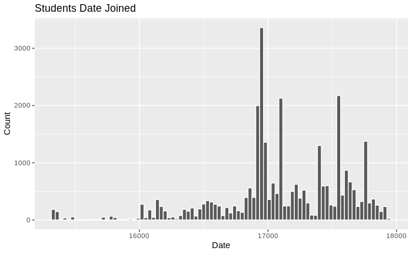

```r
# Preprocess Date Joined
students$students_date_joined <- as.Date(students$students_date_joined)
students$date_num <- as.numeric(students$students_date_joined)
# Setup Date Histogram
bin <- 30
ggplot(students, aes(date_num, ..count..)) +
  geom_histogram(binwidth = bin, colour="white") +
  ggtitle("Students Date Joined") +
  xlab("Date") +
  ylab("Count")
```

### Group

```r
# Peek at Data
head(groups, 5)
```

| groups_id | groups_group_type |
| --- | --- |
| eabbdf4029734c848a9da20779637d03 | youth program |
| 7080bf8dcf78463bb03e6863887fd715 | youth program |
| bc6fc50a2b444efc8ec47111b290ffb8 | youth program |
| 37f002e8d5e442ca8e36e972eaa55882 | youth program |
| 52419ff84d4b47bebd0b0a6c1263c296 | youth program |

```r
count(groups)
```

| n |
| --- |
| 49 |

```r
unique(groups$groups_group_type)
```

```
[1] "youth program"        "cause"                "professional network" "club"                 "competition"          "mentorship program"   "interest group"
```

```r
# Check Count of Group Type
group_df <- groups %>%
  count(groups$groups_group_type)
group_df <- data.frame(group_df)
group_df[order(group_df$n, decreasing=TRUE), ]
```

|  | groups.groups_group_type | n |
| --- | --- | --- |
| 7 | youth program | 33 |
| 6 | professional network | 8 |
| 5 | mentorship program | 3 |
| 1 | cause | 2 |
| 2 | club | 1 |
| 3 | competition | 1 |
| 4 | interest group | 1 |

```r
head(group_memberships, 5)
```

| group_memberships_group_id | group_memberships_user_id |
| --- | --- |
| eabbdf4029734c848a9da20779637d03 | 9a5aead62c344207b2624dba90985dc5 |
| eabbdf4029734c848a9da20779637d03 | ea7122da1c7b4244a2184a4f9f944053 |
| eabbdf4029734c848a9da20779637d03 | cba603f34acb4a40b3ccb53fe6681b5d |
| eabbdf4029734c848a9da20779637d03 | fa9a126e63714641ae0145557a390cab |
| eabbdf4029734c848a9da20779637d03 | 299da113c5d1420ab525106c242c9429 |

```r
count(group_memberships)
```

| n |
| --- |
| 1038 |

### Group Memberships

```r
# Perform a Group by Sum of Membership Groups
group_df <- group_memberships %>%
  count(group_memberships_user_id)
group_df <- data.frame(group_df)
group_df[order(group_df$n, decreasing=TRUE), ]
```

|  | group_memberships_user_id | n |
| --- | --- | --- |
| 472 | b0f6c44506444fb99e910dcc5836b5d8 | 14 |
| 464 | ab8d405cfdab4faf83ffe7f83944a87b | 10 |
| 2 | 018ed03f99f949739335a319e7e7027d | 6 |
| 41 | 1009f4edd679418faf1532a0b77733ae | 6 |
| 246 | 5f4b23b47304481abd3ce9263b2a43d8 | 6 |
| 44 | 1144880a2cda4f4daf5bcf35b50cbeb8 | 5 |
| 46 | 11df8341f9f64843bae56ccda1b95aed | 5 |
| 84 | 23b2a4faac2e4662945d77fb5a2eebd0 | 5 |
| 95 | 2717036e108e486694d6a498e7c2d60c | 5 |
| 152 | 3c3eeef51fc94f24b4ffc8cad04f0400 | 5 |

[output cut: 717 more lines]

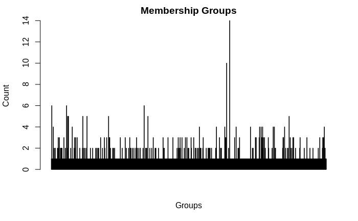

```r
# Plot Membership Counts Per Group
barplot(group_df$n, main="Membership Groups", xlab="Groups", ylab="Count")
```

```r
# Join with Groups
names(group_memberships)[1] <- "groups_id"
merge(group_memberships, groups)
```

| groups_id | group_memberships_user_id | groups_group_type |
| --- | --- | --- |
| 0b3cdc7e092041f4b8cf680bb1064144 | 34658a9edacd45968553449fe4fea212 | professional network |
| 0b3cdc7e092041f4b8cf680bb1064144 | bff374a796984bb59eb88507a093197b | professional network |
| 0b3cdc7e092041f4b8cf680bb1064144 | 1eaac5c9cfb14b94935d2a2454e1c7ef | professional network |
| 0b3cdc7e092041f4b8cf680bb1064144 | c05c97e69b6841c6aa3ab5e308ce0219 | professional network |
| 0b3cdc7e092041f4b8cf680bb1064144 | d88552308245452097227ffc5385d8d2 | professional network |
| 0b3cdc7e092041f4b8cf680bb1064144 | a0ec34bef1bf4f1aa5c500fb74908539 | professional network |
| 0b3cdc7e092041f4b8cf680bb1064144 | d44af31439ce4acfa3514a57123b1f59 | professional network |
| 0b3cdc7e092041f4b8cf680bb1064144 | 2717036e108e486694d6a498e7c2d60c | professional network |
| 0b3cdc7e092041f4b8cf680bb1064144 | 3339079a1ce1489092bba750e0c7a2b6 | professional network |
| 0b3cdc7e092041f4b8cf680bb1064144 | 1009f4edd679418faf1532a0b77733ae | professional network |

[output cut: 990 more lines]

### School Memberships

```r
head(school_memberships, 5)
```

| school_memberships_school_id | school_memberships_user_id |
| --- | --- |
| 197406 | 23dce13ca6164a73aec7a3cd56a4884d |
| 197398 | 23dce13ca6164a73aec7a3cd56a4884d |
| 199821 | 23dce13ca6164a73aec7a3cd56a4884d |
| 186239 | 9c5803ae43ca4cf6b27ea85871625116 |
| 182063 | 9c5803ae43ca4cf6b27ea85871625116 |

```r
count(school_memberships)
```

| n |
| --- |
| 5638 |

```r
group_df <- school_memberships %>%
  count(school_memberships$school_memberships_school_id)
group_df <- data.frame(group_df)
group_df[order(group_df$n, decreasing=TRUE), ]
```

|  | school_memberships.school_memberships_school_id | n |
| --- | --- | --- |
| 1730 | 196700 | 45 |
| 2521 | 200003 | 44 |
| 1721 | 196665 | 41 |
| 1779 | 196883 | 37 |
| 1654 | 196396 | 33 |
| 2162 | 198520 | 33 |
| 2590 | 200261 | 33 |
| 2069 | 198038 | 32 |
| 1651 | 196393 | 30 |
| 1815 | 197007 | 27 |

[output cut: 990 more lines]

### Professionals

```r
head(professionals, 5)
```

| professionals_id | professionals_location | professionals_industry | professionals_headline | professionals_date_joined |
| --- | --- | --- | --- | --- |
| 9ced4ce7519049c0944147afb75a8ce3 | NA | NA | NA | 2011-10-05 20:35:19 UTC+0000 |
| f718dcf6d2ec4cb0a52a9db59d7f9e67 | NA | NA | NA | 2011-10-05 20:49:21 UTC+0000 |
| 0c673e046d824ec0ad0ebe012a0673e4 | New York, New York | NA | NA | 2011-10-18 17:31:26 UTC+0000 |
| 977428d851b24183b223be0eb8619a8c | Boston, Massachusetts | NA | NA | 2011-11-09 20:39:29 UTC+0000 |
| e2d57e5041a44f489288397c9904c2b2 | NA | NA | NA | 2011-12-10 22:14:44 UTC+0000 |

```r
count(professionals)
```

| n |
| --- |
| 28152 |

```r
# Find Number of NAs Per Feature
sum(is.na(professionals$professionals_location))
```

```
[1] 3098
```

```r
sum(is.na(professionals$professionals_industry))
```

```
[1] 2576
```

```r
sum(is.na(professionals$professionals_headline))
```

```
[1] 2067
```

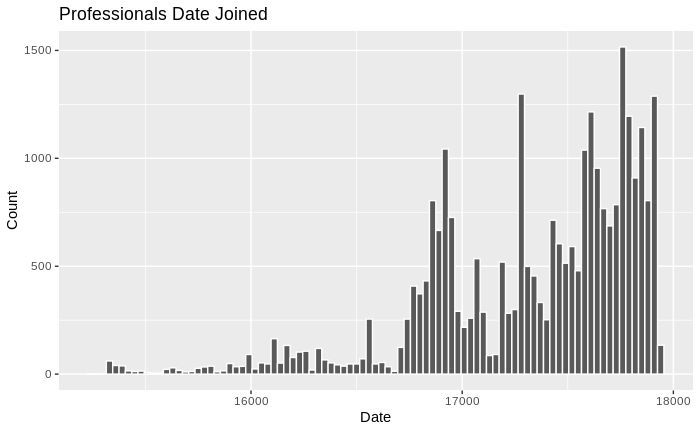

```r
# Preprocess Date Joined
professionals$professionals_date_joined <- as.Date(professionals$professionals_date_joined)
professionals$date_num <- as.numeric(professionals$professionals_date_joined)
# Setup Date Histogram
bin <- 30
ggplot(professionals, aes(date_num, ..count..)) +
  geom_histogram(binwidth = bin, colour="white") +
  ggtitle("Professionals Date Joined") +
  xlab("Date") +
  ylab("Count")
```

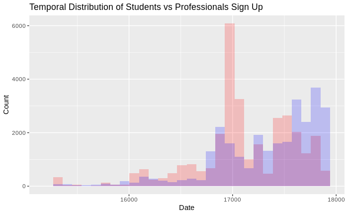

```r
# Student vs Professional Join Date Timing
joint <- rbind(
  data.frame(date_num = students$date_num, user='student', type = "Cont"),
  data.frame(date_num = professionals$date_num, user='prof', type = "Cont")
)
ggplot(joint, aes(date_num, ..count..)) +
    geom_histogram(data=subset(joint,user == 'student'),fill = "red", alpha = 0.2) +
    geom_histogram(data=subset(joint,user == 'prof'),fill = "blue", alpha = 0.2) +
    ggtitle("Temporal Distribution of Students vs Professionals Sign Up") +
    xlab("Date") +
    ylab("Count")
```

### Emails

```r
head(emails, 5)
```

| emails_id | emails_recipient_id | emails_date_sent | emails_frequency_level |
| --- | --- | --- | --- |
| 2337714 | 0c673e046d824ec0ad0ebe012a0673e4 | 2018-12-07 01:05:40 UTC+0000 | email_notification_daily |
| 2336077 | 0c673e046d824ec0ad0ebe012a0673e4 | 2018-12-06 01:14:15 UTC+0000 | email_notification_daily |
| 2314660 | 0c673e046d824ec0ad0ebe012a0673e4 | 2018-11-17 00:38:27 UTC+0000 | email_notification_daily |
| 2312639 | 0c673e046d824ec0ad0ebe012a0673e4 | 2018-11-16 00:32:19 UTC+0000 | email_notification_daily |
| 2299700 | 0c673e046d824ec0ad0ebe012a0673e4 | 2018-11-08 00:16:40 UTC+0000 | email_notification_daily |

```r
count(emails)
```

| n |
| --- |
| 1850101 |

```r
# Category Counts of Emails
group_df <- emails %>%
  count(emails$emails_frequency_level)
group_df <- data.frame(group_df)
group_df[order(group_df$n, decreasing=TRUE), ]
```

|  | emails.emails_frequency_level | n |
| --- | --- | --- |
| 1 | email_notification_daily | 1488240 |
| 2 | email_notification_immediate | 333183 |
| 3 | email_notification_weekly | 28678 |

[figure not shown]

```r
# Preprocess Date Sent
emails$emails_date_sent <- as.Date(emails$emails_date_sent)
emails$date_num <- as.numeric(emails$emails_date_sent)
# Setup Date Histogram
bin <- 30
ggplot(professionals, aes(date_num, ..count..)) +
  geom_histogram(binwidth = bin, colour="white") +
  ggtitle("Emails Date Sent") +
  xlab("Date") +
  ylab("Count")
```

### Matches

```r
head(matches, 5)
```

| matches_email_id | matches_question_id |
| --- | --- |
| 1721939 | 332a511f1569444485cf7a7a556a5e54 |
| 1665388 | 332a511f1569444485cf7a7a556a5e54 |
| 1636634 | 332a511f1569444485cf7a7a556a5e54 |
| 1635498 | 332a511f1569444485cf7a7a556a5e54 |
| 1620298 | 332a511f1569444485cf7a7a556a5e54 |

```r
count(matches)
```

| n |
| --- |
| 4316275 |

### Questions

```r
head(questions, 10)
```

| questions_id | questions_author_id | questions_date_added | questions_title | questions_body |
| --- | --- | --- | --- | --- |
| 332a511f1569444485cf7a7a556a5e54 | 8f6f374ffd834d258ab69d376dd998f5 | 2016-04-26 11:14:26 UTC+0000 | Teacher career question | What is a maths teacher? what is a maths teacher useful? #college #professor #lecture |
| eb80205482e4424cad8f16bc25aa2d9c | acccbda28edd4362ab03fb8b6fd2d67b | 2016-05-20 16:48:25 UTC+0000 | I want to become an army officer. What can I do to become an army officer? | I am Priyanka from Bangalore . Now am in 10th std . When I go to college I should not get confused on what I want to take to become army officer. So I am asking this question #military #army |
| 4ec31632938a40b98909416bdd0decff | f2c179a563024ccc927399ce529094b5 | 2017-02-08 19:13:38 UTC+0000 | Will going abroad for your first job increase your chances for jobs back home? | I'm planning on going abroad for my first job. It will be a teaching job and I don't have any serious career ideas. I don't know what job I would be working if I stay home instead so I'm assuming stay… |
| 2f6a9a99d9b24e5baa50d40d0ba50a75 | 2c30ffba444e40eabb4583b55233a5a4 | 2017-09-01 14:05:32 UTC+0000 | To become a specialist in business management, will I have to network myself? | i hear business management is a hard way to get a job if you're not known in the right areas. #business #networking |
| 5af8880460c141dbb02971a1a8369529 | aa9eb1a2ab184ebbb00dc01ab663428a | 2017-09-01 02:36:54 UTC+0000 | Are there any scholarships out there for students that are first generation and live in GA? | I'm trying to find scholarships for first year students but they all seem to be for other states besides GA. Any help??\r\n\r\n#college\r\n#scholarships \r\n#highschoolsenior \r\n#firstgeneration \r\n |
| 7c336403258f4da3a2e0955742c76462 | d1e4587c0e784c62bc27eb8d16a07f38 | 2017-03-01 04:27:08 UTC+0000 | How many years of coege do you need to be an engineer | To be an engineer #united-states |
| be3c5edfdb07423e955e9b2d7f186bce | 71b4554d4a824253aa28287372c55797 | 2017-09-01 04:59:38 UTC+0000 | I want to become a doctor because of my great interest in science and helping people, but can I major in something that isn't science oriented? | I am a musician and want to pursue that in college as well, but I don't want my love of science to supersede that. \r\n#medicine #music |
| 0f1d6a4f276c4a05878dd48e03e52289 | 585ac233015447cc9e9a217044e515e1 | 2016-05-19 22:16:25 UTC+0000 | what kind of college could i go to for a soccer player | I like soccer because i been playing sense i was 6 years old. soccer is my best sport i played for 1/7 years.every year. #college #soccer #building |
| d4999cdc470049a1a3382c4b5f14a7aa | 654e1d6fd5b947249c0e70658d01b2ac | 2017-08-31 19:20:47 UTC+0000 | What are the college classes like for and graphics design major? | I'm asking because I was thinking about choosing that career as an major for when I go to college. I though why not ask someone who has went to college and graduated with and degree in that subject. #… |
| e214acfbe6644d65b889a3268828db9d | 16908136951a48ed942738822cedd5c2 | 2012-09-09 05:33:25 UTC+0000 | what does it take to be an anesthesiologist? | I am a sophomore who is interested in learning more about anesthesiologist. What steps do they have to take in order to become a anesthesiologist? Is it fun or hard? #doctor #healthcare #experience #a… |

```r
count(questions)
```

| n |
| --- |
| 23931 |

```r
questions <- data.frame(questions)
```

### Question Scores

```r
head(questions_score, 5)
```

| id | score |
| --- | --- |
| 38436aadef3d4b608ad089cf53ab0fe7 | 5 |
| edb8c179c5d64c9cb812a59a32045f55 | 4 |
| 333464d7484b43e3866e86096bc4ddb9 | 6 |
| 4b995e60b99d4ee18346e893e007cb8f | 6 |
| f6b9ca94aed04ba28256492708e74f60 | 6 |

```r
count(questions_score)
```

| n |
| --- |
| 23928 |

```r
# Obtain Score Frequency
group_df <- questions_score%>%
  count(questions_score$score)
group_df <- data.frame(group_df)
group_df[order(group_df$n, decreasing=TRUE), ]
```

|  | questions_score.score | n |
| --- | --- | --- |
| 2 | 1 | 7311 |
| 3 | 2 | 6120 |
| 4 | 3 | 3893 |
| 5 | 4 | 2583 |
| 6 | 5 | 1370 |
| 1 | 0 | 732 |
| 7 | 6 | 676 |
| 8 | 7 | 376 |
| 9 | 8 | 197 |
| 10 | 9 | 140 |

[output cut: 65 more lines]

[figure not shown]

```r
qplot(group_df$n, geom="histogram", bins=30) +
  ggtitle("Distribution of Question Scores") +
  xlab("Score") +
  ylab("Count")
```

## Exploratory Data Analysis on the Teachers Income Dataset

Another dataset we worked with is from the National Center for Education Statistics. They conduct various statistical studies to evaluate the state of Public Education System in the United States. For our analysis, we focused on using data between 2015 and 2016 on Annual Estimated Average Salaries for Primary and Secondary School Teachers in the United States for each state.

```r
head(salaries)
```

| X1 | 2015 | 2016 |
| --- | --- | --- |
| Alabama | 49410 | 48868 |
| Alaska | 68684 | 68138 |
| Arizona | 48087 | 47403 |
| Arkansas | 49105 | 48616 |
| California | 78599 | 78711 |
| Colorado | 47004 | 46506 |

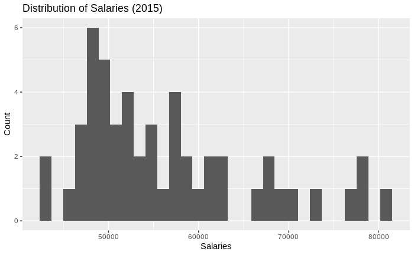

```r
qplot(salaries$`2015`, geom="histogram", bins=30) +
  ggtitle("Distribution of Salaries (2015)") +
  xlab("Salaries") +
  ylab("Count")
```

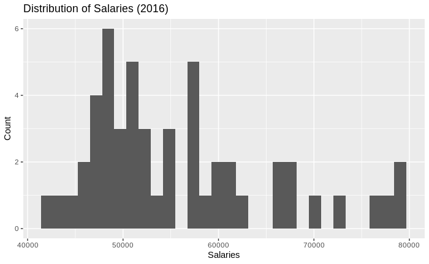

```r
qplot(salaries$`2016`, geom="histogram", bins=30) +
  ggtitle("Distribution of Salaries (2016)") +
  xlab("Salaries") +
  ylab("Count")
```

## Data Extraction and Preprocessing

For the purpose of this project, we only wanted to see the data for the students and questions that are related to the education field. Therefore, we picked up some of the keywords as “tags of interests”, and use this vector to filter out the questions and students that seem to be interested in this particular field.

Then, we joined tables into one question-centric data frame. In this process, we created binary flags indicating whether or not each question has specific tags that we are interested in boolean value in order to avoid duplicated data instances due to the joins of one-to-many relationship.

Furthermore, in order to make the analysis easy, we got rid of some of the data that included NAs.

```r
usersOfInterests <- extractStudentsWithInterest(tags, tag_users, students, interest)
head(usersOfInterests)
```

| userId | students_location | students_date_joined | date_num |
| --- | --- | --- | --- |
| 6e795d8d47de4676a8d5cef449bef740 | United States | 2012-03-08 | 15407 |
| 3040e8fc5c03478d9c9f0ed96328f4ed | Boise, Idaho | 2014-01-28 | 16098 |
| 70467fb564ec4387b8e118ca07ca4ceb | Sacramento, California | 2014-02-12 | 16113 |
| 8b291da8e6d04b10b1ac505e240dcf8a | Las Vegas, Nevada | 2014-02-25 | 16126 |
| 3d1d9819c53b43fa9b56d824a3a8b9c7 | Clinton, Maryland | 2014-03-18 | 16147 |
| a2508a2564264ad8915c9280248c445e | New York, New York | 2014-03-25 | 16154 |

```r
# We generate a question-centric table for the list of questions people asked.
questionsOfInterests <- extractQuestionsOfInterests(tags, tag_questions, questions, questions_score, interest)
```

| tag_questions_question_id | teaching | teacher | education | high school | school |
| --- | --- | --- | --- | --- | --- |
| 000b30fb534b41f7b716fa9ebf9c3f35 | 1 | 0 | 0 | 1 | 0 |
| 00683da3fd6245898d7346780dfa2d63 | 0 | 0 | 0 | 1 | 0 |
| 007113a6f5e44b78bcd412d7d7772ea2 | 1 | 0 | 0 | 0 | 0 |
| 00b14086448d4abb9f9f26e22cf9b8dc | 0 | 1 | 0 | 0 | 0 |
| 00c69523c1f24d62937f6c6b36a0dc3e | 0 | 0 | 0 | 1 | 0 |
| 00cac59c62344eb98bd2c2c88035a382 | 0 | 0 | 1 | 0 | 0 |
| 00d7b4b588b64ece8c8cb941bc8a0433 | 0 | 0 | 0 | 1 | 0 |
| 00faf7f2ead047f6ad8379a53bea12f1 | 0 | 0 | 0 | 1 | 0 |
| 011481de990f4a8e8b72556367bc578b | 0 | 1 | 0 | 0 | 0 |
| 011571f7a5fc4fbab59e34531e1b5456 | 0 | 1 | 0 | 0 | 0 |

[output cut: 990 more lines]

```r
head(questionsOfInterests)
```

|  | id | userId | questions_date_added | questions_title | questions_body | teaching | teacher | education | high school | school | score |
| --- | --- | --- | --- | --- | --- | --- | --- | --- | --- | --- | --- |
| 1 | 000b30fb534b41f7b716fa9ebf9c3f35 | 7ceced847e2145e2994f6c64b64010a6 | 2016-05-19 18:02:44 UTC+0000 | Is the Demand for Gym Teachers diminishing? | Hi, I'm currently debating on whether to pursue a career in Exercise Sciences and become a Gym Teacher. However upon researching the job some more, some say that the demand for Gym Teachers is vanishi… | 1 | 0 | 0 | 1 | 0 | 2 |
| 2 | 00683da3fd6245898d7346780dfa2d63 | df0676dda0454bbbbc4ad697e9149bf7 | 2018-05-30 00:41:20 UTC+0000 | What skill sets make for a better grad school application? | Hi.\r\nI'm looking to start building a resume with experience that'll reasonably prepare me for applying to graduate school. What kinds of opportunities should I be searching for to accomplish this?\r… | 0 | 0 | 0 | 1 | 0 | 2 |
| 3 | 007113a6f5e44b78bcd412d7d7772ea2 | a624bc237424478db19a0aedda4d0c0e | 2016-07-01 09:18:57 UTC+0000 | What is Material science enginering | for my career #teaching | 1 | 0 | 0 | 0 | 0 | 2 |
| 4 | 00b14086448d4abb9f9f26e22cf9b8dc | 19dc4b270a144bdfbed9f3c781b60ccc | 2018-08-27 13:23:43 UTC+0000 | How do I avoid student debt? | As a chemistry major, all I can think about is the hundreds of thousands of dollars I'm going to spend on college. How, other than scholarships, am I supposed to avoid going into debt when college is … | 0 | 1 | 0 | 0 | 0 | 2 |
| 5 | 00c69523c1f24d62937f6c6b36a0dc3e | 3f1209b1148040419ae1e33e748cf3df | 2016-09-05 17:58:35 UTC+0000 | I need help with my extracuricular activities! | Okay so highschool has started and I'm not apart of anything. I'm not in band, orchestra, sports team, theater or anything else. Club rush is coming up and I'm planning on joining a few clubs and bein… | 0 | 0 | 0 | 1 | 0 | 8 |
| 6 | 00cac59c62344eb98bd2c2c88035a382 | f1373c7d3e3b4d549088c91e7c157dd7 | 2014-11-26 23:50:57 UTC+0000 | How would I go about becoming a secondary education teacher/school administrator? | I am a high school junior at Boston Collegiate with a solid GPA and lots of extracurricular activities that I enjoy partaking in. I love tutoring kids of all ages, from homework help to studying for q… | 0 | 0 | 1 | 0 | 0 | 4 |

```r
# We then perform a merge between the two tables as a single table.
combinedData <- merge(x = questionsOfInterests, y = usersOfInterests, by = "userId", all.X = TRUE)
names(combinedData)[names(combinedData) == 'high school'] <- 'high'
combinedData
```

| userId | id | questions_date_added | questions_title | questions_body | teaching | teacher | education | high | school | score | students_location | students_date_joined | date_num |
| --- | --- | --- | --- | --- | --- | --- | --- | --- | --- | --- | --- | --- | --- |
| 008d073f619946ad80d2eac08be12020 | 1e98e41b2881408a95eab85e2c153938 | 2016-04-30 06:26:04 UTC+0000 | I want to Join Indian Army | I am Ankit from Gurgaon India. I am in 10th class. I want to Join Indian Army. please Guide Me how can i join Indian Army . #teaching #teacher #professor #educator #army | 1 | 1 | 0 | 0 | 0 | 2 | Gurugram, Haryana, India | 2016-04-30 | 16921 |
| 010bb8b6e75746e6a7d98cd102b63d78 | b0305e7058344462803e9da3afa95631 | 2016-06-28 07:46:19 UTC+0000 | Can you describe the process for finding job leads? | for my career #teaching | 1 | 0 | 0 | 0 | 0 | 2 | Sriperumbudur, Tamil Nadu, India | 2016-06-27 | 16979 |
| 01633de002284698a5430fd5d5f93810 | f54945c5539b42d895d4389436b7cf26 | 2016-06-23 10:19:37 UTC+0000 | what i want to study for air force | i want help for this course so iam asking this question #teaching #teacher #professor #colleges #scientist #engineers #aeronautics #lecturer #merits | 1 | 1 | 0 | 0 | 0 | 6 | Bengaluru, Karnataka, India | 2016-05-06 | 16927 |
| 033daeffbcd541b89dea4894efc6cc7f | 8c84a272d536437c85a39282b284d6f0 | 2016-06-28 06:24:40 UTC+0000 | What’s your take on survival jobs? | for my life and career #teaching | 1 | 0 | 0 | 0 | 0 | 4 | Sriperumbudur, Tamil Nadu, India | 2016-06-22 | 16974 |
| 03d6124c907e4f78b744ec72cc02c1de | 146da17f56974a6e8759a2ec043a5de6 | 2016-05-15 04:38:59 UTC+0000 | What does a person do while getting their teaching credential? | I want to become a teacher however I am unsure exactly what exactly one does after getting their bachelors degree. Specifically whay someone hasto do to receive their teaching credential. #teacher | 0 | 1 | 0 | 0 | 0 | 3 | San Bernardino, California | 2016-05-15 | 16936 |
| 040bc1cd485040e5b9480a8e44e6acff | d56ec2b03c8a4ff59d980a8db8da1d21 | 2016-04-26 11:27:32 UTC+0000 | how to increase programming language in computer science? which programming language shall i prefer? | I like programming language very much ...kindly help #education #k-12-education #community #listening | 0 | 0 | 1 | 0 | 0 | 2 | Chennai, Tamil Nadu, India | 2016-04-26 | 16917 |
| 0433ce9ff0e84a6ebd68cf22bf1b9e6b | 1e0425634e7646668edc661f73b5acb1 | 2016-05-13 01:39:13 UTC+0000 | Is it difficult to become alternatively certified? | Should I choose to graduate with a degree in biology, how difficult will it be to be alternatively certified to teach public school? #teaching #teacher | 1 | 1 | 0 | 0 | 0 | 3 | Stanford, California | 2016-05-13 | 16934 |
| 04dbd8c22cd84bf5931bf242171c0ae3 | 06a50c2d9c0042199ba84247d71ee621 | 2016-05-12 13:26:02 UTC+0000 | If you get a degree in Math Education can you teach accounting? | I would love to teach math but I'm not sure if I would like to teach Algebra and Calculus and stuff like that. But I absolutely love accounting and would like to teach that. #education #mathematics #k… | 0 | 0 | 1 | 0 | 0 | 1 | Dayton, Ohio | 2016-05-12 | 16933 |
| 050158571ce04b73a96ac8fa4ae22ff7 | dff420a085a64a8bb23f57167aa0f25d | 2016-08-18 21:45:55 UTC+0000 | What is it like being an anesthesiologist? | I plan to become an anesthesiologist but people have said that you don't get much interaction with patients (which I love). So I want to know what it is like being an anesthesiologist and whether I sh… | 0 | 1 | 0 | 0 | 0 | 5 | Centreville, Virginia | 2016-08-18 | 17031 |
| 05c8a141dcc343709361bf456b860b58 | 7dd2a426be334f149232822561290cb6 | 2016-06-25 03:12:31 UTC+0000 | I enjoy kids, and would love to work with children although I also enjoy makeup but have no clue where I should start. | I'm an upcoming senior with absolutely no clue on what I will do after high school. I have in mind some careers I'd like to persue but don't know exactly how to decide or where and how to start. #psyc… | 1 | 1 | 0 | 0 | 0 | 2 | Fullerton, California | 2016-06-25 | 16977 |

[output cut: 395 more lines]

## Data Analysis

### Supervised Learning

We were interested in observing whether or not the choice of tags or some features of students somehow affect the quality of the question, rated as score. In order to answer this question, we used some of the supervised technique such as tree, random forest, and generalized linear model that takes in given features of students and binary flags indicating what tags students used and predict the score.

First we perform some basic analysis on the data.

```r
x <- as.list(as.data.frame(combinedData$score))
lapply(x, mean)
```

```
$`combinedData$score`
[1] 4.032099
```

```r
lapply(x, quantile, probs = 1:3/4)
```

```
$`combinedData$score`
25% 50% 75%
  2   3   4
```

```r
sapply(x, quantile)
```

```
     combinedData$score
0%                    0
25%                   2
50%                   3
75%                   4
100%                 90
```

#### Train-Test Split

First we split our dataset, 80% for training and 20% for testing.

```r
# We used 80-20 split for the training and test data
n <- nrow(combinedData)
test_idx <- sample.int(n, size = round(0.20 * n))
train <- combinedData[-test_idx, ]
test <- combinedData[test_idx, ]
```

#### Linear Model

As a baseline, we train a linear model to our data.

```r
mod_logit <- glm(score ~ teacher + teaching + high + school + education, data = train, family = "gaussian")
logitProb <- predict(mod_logit, newdata = test, type = "response")
```

```
prediction from a rank-deficient fit may be misleading
```

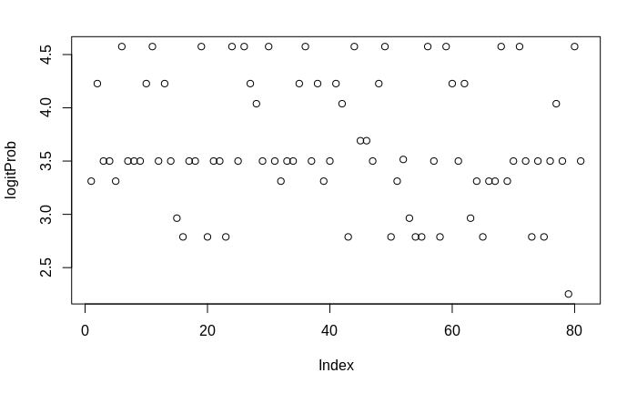

```r
plot(logitProb)
```

```r
test <- test %>%
  mutate(regression = logitProb)
```

#### Random Forest

To train a better model, we decided to train a Random Forest model.

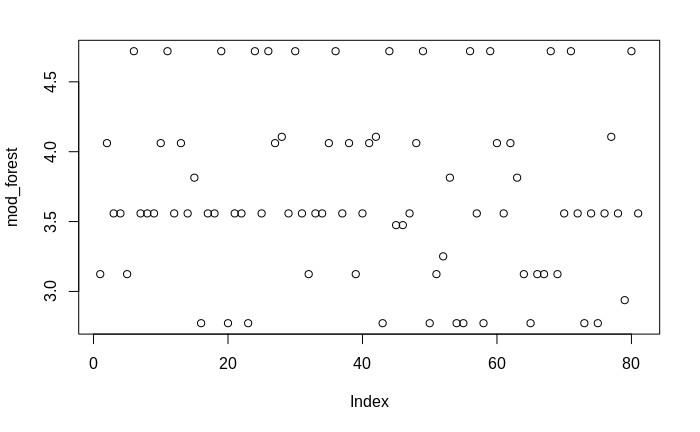

```r
mod_forest <- randomForest(score ~ teacher + teaching + high + school + education, data = train, ntree = 100, mtry = 2)
mod_forest <- predict(mod_forest, newdata = test, type = "response")
plot(mod_forest)
```

```r
test <- test %>%
  mutate(forest = mod_forest)
```

#### Simple Tree

We also train a simple tree model as well for additional benchmarking.

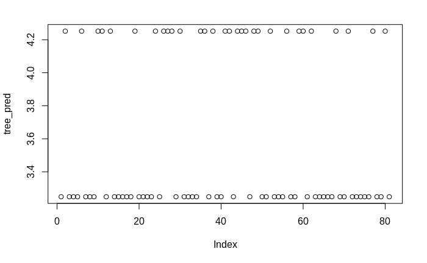

```r
mod_tree <- rpart(score ~ teacher + teaching + high + school + education, data = train)
tree_pred <- predict(mod_tree, newdata = test, type = "vector")
plot(tree_pred)
```

```r
test <- test %>%
  mutate(tree = tree_pred)
```

### Accuracy Check

```r
# In order to check the accuracy, we used rmse
resultTest <- test %>%
  select(regression, tree, forest, score) %>%
  mutate(regression_diff = (as.double(regression) - score) ** 2,
         tree_diff = (as.double(tree) - score) ** 2,
         forest_diff = (as.double(forest) - score) ** 2)
rmseRegression <- sqrt(mean(resultTest$regression_diff))
rmseTree <- sqrt(mean(resultTest$tree_diff))
rmseForest <- sqrt(mean(resultTest$forest_diff))
rmseRegression
```

```
[1] 12.94674
```

```r
rmseTree
```

```
[1] 12.96099
```

```r
rmseForest
```

```
[1] 12.93552
```

### Unsupervised Learning

```r
samples = sample(questionsOfInterests, 100, replace=FALSE)
it_data = itoken(samples$questions_body,
       preprocessor = tolower,
       tokenizer = word_tokenizer,
       ids = samples$id,
       progressbar = FALSE,
       na.rm=TRUE)
vocab = create_vocabulary(it_data)
vectorizer = vocab_vectorizer(vocab)
dtm_data = create_dtm(it_data, vectorizer)
# Define Tf-idf Model
tfidf = TfIdf$new()
tfidf_data = fit_transform(dtm_data, tfidf)
vectors = transform(tfidf_data, tfidf)
tf_mat <- TermDocFreq(dtm_data)
tfidf <- t(dtm_data[ , tf_mat$term ]) * tf_mat$idf
tfidf <- t(tfidf)
csim <- tfidf / sqrt(rowSums(tfidf * tfidf))
csim <- csim %*% t(csim)
cdist <- as.dist(1 - csim)
```

### Hierarchical Clustering of Questions

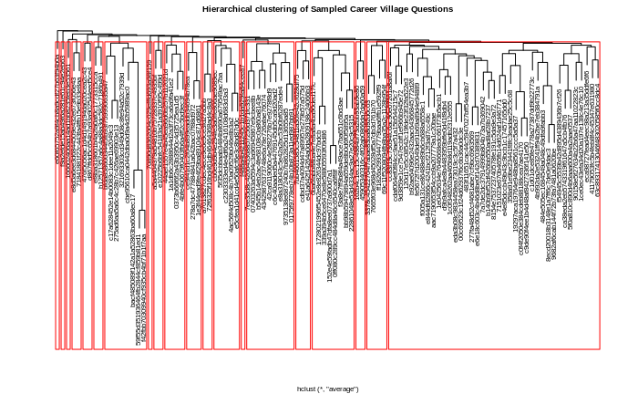

```r
hc <- hclust(cdist, method = "average")
clustering <- cutree(hc, 20)
par(cex=0.5)
plot(hc, main = "Hierarchical clustering of Sampled Career Village Questions", ylab = "", xlab = "", yaxt = "n")
rect.hclust(hc, 20, border = "red")
```

Based on our findings, it seems there are some clusters that appear with regards to different topics.

```r
# Preproces Question Title Data
docs <- Corpus(VectorSource(questionsOfInterests$questions_title))
toSpace <- content_transformer(function (x , pattern ) gsub(pattern, " ", x))
docs <- tm_map(docs, toSpace, "/")
```

[output not shown]

```r
docs <- tm_map(docs, toSpace, "@")
```

[output not shown]

```r
docs <- tm_map(docs, toSpace, "\\|")
```

[output not shown]

```r
docs <- tm_map(docs, content_transformer(tolower))
```

[output not shown]

```r
docs <- tm_map(docs, removeNumbers)
```

[output not shown]

```r
docs <- tm_map(docs, removeWords, stopwords("english"))
```

[output not shown]

```r
docs <- tm_map(docs, removePunctuation)
```

[output not shown]

```r
docs <- tm_map(docs, stripWhitespace)
```

[output not shown]

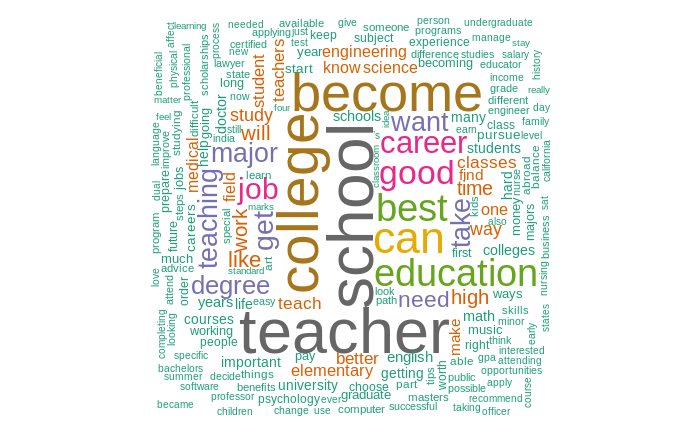

```r
# Word Cloud Visualization from Cluster
dtm <- TermDocumentMatrix(docs)
m <- as.matrix(dtm)
v <- sort(rowSums(m),decreasing=TRUE)
d <- data.frame(word = names(v),freq=v)
wordcloud(words = d$word, freq = d$freq, min.freq = 1,
          max.words=200, random.order=FALSE, rot.per=0.35,
          colors=brewer.pal(8, "Dark2"))
```

### Data Visualizations

Teacher Salary vs Student Interest vs Professionals Avaiability Per State

Identify Student Interest Per State

```r
# Identify Relative Interest of Students by State
st_interest <- data.frame()
for (st in state.name) {
  res <- dplyr::filter(usersOfInterests, grepl(st, usersOfInterests$students_location))
  st_interest <- rbind(st_interest, res)
}
# Persist Total Count
total_count <- nrow(st_interest)
# Normalize Location Data
Pattern = paste0(paste0(".*\\b(", paste0(state.name, collapse="|")), ")\\b.*")
st_interest$students_location = sub(Pattern, "\\1", st_interest$students_location)
state_count <- st_interest %>%
  group_by(students_location) %>%
  count()
state_count$int_ratio <- state_count$n / total_count
state_count
```

| students_location | n | int_ratio |
| --- | --- | --- |
| Alabama | 1 | 0.004926108 |
| Arizona | 2 | 0.009852217 |
| California | 36 | 0.177339901 |
| Colorado | 1 | 0.004926108 |
| Connecticut | 2 | 0.009852217 |
| Delaware | 1 | 0.004926108 |
| Florida | 10 | 0.049261084 |
| Georgia | 6 | 0.029556650 |
| Idaho | 3 | 0.014778325 |
| Illinois | 11 | 0.054187192 |

[output cut: 32 more lines]

Identify Number of Professionals Per State

```r
# Filter Professionals by States
pr_counts <- data.frame()
for (st in state.name) {
  res <- dplyr::filter(professionals, grepl(st, professionals$professionals_location))
  pr_counts <- rbind(pr_counts, res)
}
# Filter by Education
pr_counts <- filter(pr_counts, pr_counts$professionals_industry == "Education")
# Persist Total Count
total_count <- nrow(pr_counts)
# Normalize Location Data
Pattern = paste0(paste0(".*\\b(", paste0(state.name, collapse="|")), ")\\b.*")
pr_counts$professionals_location = sub(Pattern, "\\1", pr_counts$professionals_location)
prof_counts <- pr_counts %>%
  group_by(professionals_location) %>%
  count()
prof_counts
```

| professionals_location | n |
| --- | --- |
| Alabama | 1 |
| Arkansas | 1 |
| California | 4 |
| Connecticut | 2 |
| Florida | 4 |
| Georgia | 7 |
| Illinois | 3 |
| Indiana | 1 |
| Kentucky | 1 |
| Maryland | 3 |

[output cut: 9 more lines]

Merge with Salary Dataset

```r
# Load Salary Dataset
salaries <- read_csv("../data/tabn211.60.csv")
head(salaries)
```

| X1 | 2015 | 2016 |
| --- | --- | --- |
| Alabama | 49410 | 48868 |
| Alaska | 68684 | 68138 |
| Arizona | 48087 | 47403 |
| Arkansas | 49105 | 48616 |
| California | 78599 | 78711 |
| Colorado | 47004 | 46506 |

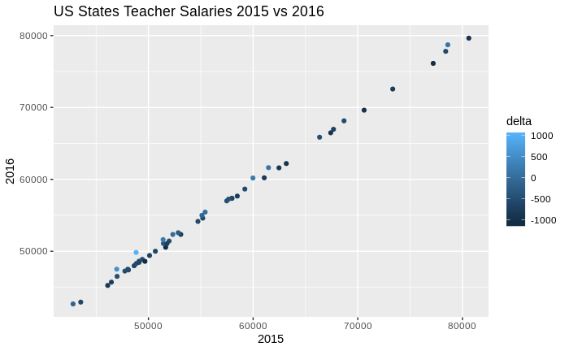

```r
# Visualize Relationships Between Two Years
salaries$delta <- salaries$`2016` - salaries$`2015`
ggplot(salaries, aes(x=`2015`, y=`2016`)) +
  geom_point(aes(color=delta)) +
  ggtitle("US States Teacher Salaries 2015 vs 2016") +
  xlab("2015") +
  ylab("2016")
```

```r
# Compute Average Salaries Two Years
salaries$avg <- (salaries$`2016` + salaries$`2015`) / 2
salaries
```

| X1 | 2015 | 2016 | delta | avg |
| --- | --- | --- | --- | --- |
| Alabama | 49410 | 48868 | -542 | 49139.0 |
| Alaska | 68684 | 68138 | -546 | 68411.0 |
| Arizona | 48087 | 47403 | -684 | 47745.0 |
| Arkansas | 49105 | 48616 | -489 | 48860.5 |
| California | 78599 | 78711 | 112 | 78655.0 |
| Colorado | 47004 | 46506 | -498 | 46755.0 |
| Connecticut | 73338 | 72561 | -777 | 72949.5 |
| Delaware | 61063 | 60214 | -849 | 60638.5 |
| District of Columbia | 77205 | 76131 | -1074 | 76668.0 |
| Florida | 50104 | 49407 | -697 | 49755.5 |

[output cut: 41 more lines]

```r
# Rename Columns for Consistency
names(salaries)[1] <- "state"
names(state_count)[1] <- "state"
names(prof_counts)[1] <- "state"
names(state_count)[2] <- "st_cnt"
names(state_count)[3] <- "st_ratio"
names(prof_counts)[2] <- "pf_cnt"
# Merge Operation
merge_df <- merge(salaries, state_count, by="state", all = TRUE)
merge_df <- merge(merge_df, prof_counts, by="state", all = TRUE)
merge_df
```

| state | 2015 | 2016 | delta | avg | st_cnt | st_ratio | pf_cnt |
| --- | --- | --- | --- | --- | --- | --- | --- |
| Alabama | 49410 | 48868 | -542 | 49139.0 | 1 | 0.004926108 | 1 |
| Alaska | 68684 | 68138 | -546 | 68411.0 | NA | NA | NA |
| Arizona | 48087 | 47403 | -684 | 47745.0 | 2 | 0.009852217 | NA |
| Arkansas | 49105 | 48616 | -489 | 48860.5 | NA | NA | 1 |
| California | 78599 | 78711 | 112 | 78655.0 | 36 | 0.177339901 | 4 |
| Colorado | 47004 | 46506 | -498 | 46755.0 | 1 | 0.004926108 | NA |
| Connecticut | 73338 | 72561 | -777 | 72949.5 | 2 | 0.009852217 | 2 |
| Delaware | 61063 | 60214 | -849 | 60638.5 | 1 | 0.004926108 | NA |
| District of Columbia | 77205 | 76131 | -1074 | 76668.0 | NA | NA | NA |
| Florida | 50104 | 49407 | -697 | 49755.5 | 10 | 0.049261084 | 4 |

[output cut: 41 more lines]

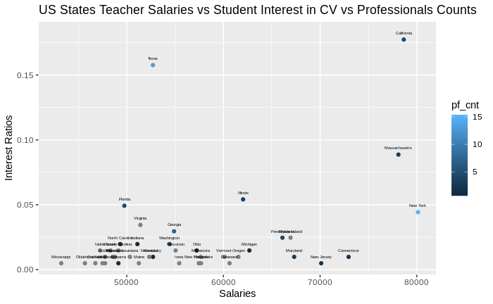

```r
# Build Visualization
ggplot(merge_df, aes(x=avg, y=st_ratio)) +
  geom_point(aes(color=pf_cnt)) +
  geom_text(label=merge_df$state, size=1.5, nudge_x = 0, nudge_y = 0.005) +
  ggtitle("US States Teacher Salaries vs Student Interest in CV vs Professionals Counts") +
  xlab("Salaries") +
  ylab("Interest Ratios")
```

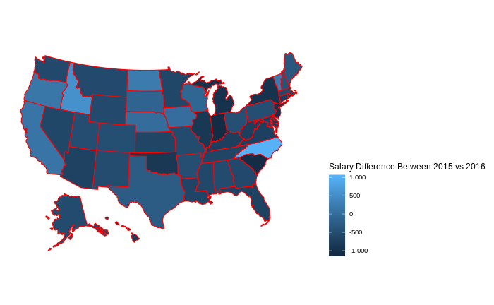

```r
plot_usmap(data = salaries, values = "delta", lines = "red") +
  scale_fill_continuous(name = "Salary Difference Between 2015 vs 2016", label = scales::comma) +
  theme(legend.position = "right")
```

## Conclusions

Based on the analysis, we find that there are several things we can do to help the public education sector improve: 1. We can allocate funding to parts of the US that are not really paying their teachers so that we can increase the chance of interest of students to become teachers. 2. Career Village can work with the public - especially the states in those bottom left corner that aren’t recieving funding to have both teachers first join, then inviting students to join as well. 3. For this we need to make sure that students are able to attend college, and thus scholarships and other incentives to obtain a higher educational degree should be encouraged in these states.